# Arboles de decisión

Domingo José Caballero Navarro  
domingojcn@gmail.com

## Índice

- 1. Introducción
- 2. Lluvia en Australia
- 3. Normalización de variables discretas
- 4. Árbol de decisión con SciKit
- 5. Comparación modificando parámetros

# 1. Introducción

El objetivo de esta libreta, `Parte 1` de nuestra práctica, es llevar a cabo un estudio de un clasificador ya implementado de la librería `scikit-learn`, para la predicción de la lluvia en Australia.

Para ello tendremos que hacer uso de lo visto anteriormente en la práctica 0 donde podiamos ver gráficamenete como se comportaba cada variable y como estaba relacianada, ayundandonos así a realizar un estudio previo al clasificador y otro posteriormente. Además, deberemos hacer un tratamiento sobre el conjunto de datos para que pueda ser utilizado por `scikit`.

# 2. Lluvia en Australia

El conjunto de datos *weatherAUS* proporciona diversas medidas sobre la situación meteorológica en distintas zonas de Australia: temperatura mínima, temperatura máxima, humedad, dirección del viento, presión atmosférica...; así como una predicción de si llovera mañana ('No' o 'Yes').

Este conjunto de datos esta compuesto por variables categóricas y variables continuas, para implementar el clasificador necesitamos que todas sean cuantitativas por lo que tendremos que hacer un tratamiento de datos a dichas variables.

Para comenzar, importaremos todo lo necesario para el desarrollo del análisis de los conjunto de datos con `Seaborn` y para el posterior clasificador con `Sklearn`. Tendremos que importar las siguientes librearias: [Numpy](https://numpy.org/doc/stable/reference/), [Pandas](https://pandas.pydata.org/docs/reference/index.html), [Seaborn](https://seaborn.pydata.org/api.html), [Pyplot](https://matplotlib.org/stable/api/_as_gen/matplotlib.pyplot.html), [Graphviz](https://graphviz.readthedocs.io/en/stable/api.html), [Sklearn Tree](https://scikit-learn.org/stable/modules/generated/sklearn.tree.DecisionTreeClassifier.html) y [Sklearn Metrics](https://scikit-learn.org/stable/modules/model_evaluation.html) (llevan acompañados un enlace sobre información oficial).

```python
import numpy as np
import pandas as pd
import seaborn as sns
import matplotlib.pyplot as plt
import graphviz
import matplotlib
from sklearn import tree
from sklearn.metrics import accuracy_score, roc_auc_score
```

```python
weather = pd.read_csv("weatherAUS.csv", sep = ",")
del(weather['Date']) # Eliminamos Date dado que no nos aporta nada.
```

```python
weather
```

|  | Location | MinTemp | MaxTemp | Rainfall | Evaporation | Sunshine | WindGustDir | WindGustSpeed | WindDir9am | WindDir3pm | ... | Humidity9am | Humidity3pm | Pressure9am | Pressure3pm | Cloud9am | Cloud3pm | Temp9am | Temp3pm | RainToday | RainTomorrow |
| --- | --- | --- | --- | --- | --- | --- | --- | --- | --- | --- | --- | --- | --- | --- | --- | --- | --- | --- | --- | --- | --- |
| 0 | Albury | 13.4 | 22.9 | 0.6 | NaN | NaN | W | 44.0 | W | WNW | ... | 71.0 | 22.0 | 1007.7 | 1007.1 | 8.0 | NaN | 16.9 | 21.8 | No | No |
| 1 | Albury | 7.4 | 25.1 | 0.0 | NaN | NaN | WNW | 44.0 | NNW | WSW | ... | 44.0 | 25.0 | 1010.6 | 1007.8 | NaN | NaN | 17.2 | 24.3 | No | No |
| 2 | Albury | 12.9 | 25.7 | 0.0 | NaN | NaN | WSW | 46.0 | W | WSW | ... | 38.0 | 30.0 | 1007.6 | 1008.7 | NaN | 2.0 | 21.0 | 23.2 | No | No |
| 3 | Albury | 9.2 | 28.0 | 0.0 | NaN | NaN | NE | 24.0 | SE | E | ... | 45.0 | 16.0 | 1017.6 | 1012.8 | NaN | NaN | 18.1 | 26.5 | No | No |
| 4 | Albury | 17.5 | 32.3 | 1.0 | NaN | NaN | W | 41.0 | ENE | NW | ... | 82.0 | 33.0 | 1010.8 | 1006.0 | 7.0 | 8.0 | 17.8 | 29.7 | No | No |
| ... | ... | ... | ... | ... | ... | ... | ... | ... | ... | ... | ... | ... | ... | ... | ... | ... | ... | ... | ... | ... | ... |
| 145455 | Uluru | 2.8 | 23.4 | 0.0 | NaN | NaN | E | 31.0 | SE | ENE | ... | 51.0 | 24.0 | 1024.6 | 1020.3 | NaN | NaN | 10.1 | 22.4 | No | No |
| 145456 | Uluru | 3.6 | 25.3 | 0.0 | NaN | NaN | NNW | 22.0 | SE | N | ... | 56.0 | 21.0 | 1023.5 | 1019.1 | NaN | NaN | 10.9 | 24.5 | No | No |
| 145457 | Uluru | 5.4 | 26.9 | 0.0 | NaN | NaN | N | 37.0 | SE | WNW | ... | 53.0 | 24.0 | 1021.0 | 1016.8 | NaN | NaN | 12.5 | 26.1 | No | No |
| 145458 | Uluru | 7.8 | 27.0 | 0.0 | NaN | NaN | SE | 28.0 | SSE | N | ... | 51.0 | 24.0 | 1019.4 | 1016.5 | 3.0 | 2.0 | 15.1 | 26.0 | No | No |
| 145459 | Uluru | 14.9 | NaN | 0.0 | NaN | NaN | NaN | NaN | ESE | ESE | ... | 62.0 | 36.0 | 1020.2 | 1017.9 | 8.0 | 8.0 | 15.0 | 20.9 | No | NaN |

145460 rows × 22 columns

A continuación, guardamos los elementos más importante en nuestro conjunto de datos: ciudades, variables, atributos y la variable clase a predecir, en este caso RainTomorrow.

```python
cities = weather['Location'].unique()
features = weather.columns
attributes = features[:-1] # Guardamos el conjunto de atributos
target = features[-1] # Sacamos la clase a predecir
print("Ciudades:\n\n",cities,"\n")
print("Categorias:\n\n",features,"\n")
print("Atributos:\n\n",attributes,"\n")
print("Target:\n\n",target,"\n")
```

```
Ciudades:

 ['Albury' 'BadgerysCreek' 'Cobar' 'CoffsHarbour' 'Moree' 'Newcastle'
 'NorahHead' 'NorfolkIsland' 'Penrith' 'Richmond' 'Sydney' 'SydneyAirport'
 'WaggaWagga' 'Williamtown' 'Wollongong' 'Canberra' 'Tuggeranong'
 'MountGinini' 'Ballarat' 'Bendigo' 'Sale' 'MelbourneAirport' 'Melbourne'
 'Mildura' 'Nhil' 'Portland' 'Watsonia' 'Dartmoor' 'Brisbane' 'Cairns'
 'GoldCoast' 'Townsville' 'Adelaide' 'MountGambier' 'Nuriootpa' 'Woomera'
 'Albany' 'Witchcliffe' 'PearceRAAF' 'PerthAirport' 'Perth' 'SalmonGums'
 'Walpole' 'Hobart' 'Launceston' 'AliceSprings' 'Darwin' 'Katherine'
 'Uluru']

Categorias:

 Index(['Location', 'MinTemp', 'MaxTemp', 'Rainfall', 'Evaporation', 'Sunshine',
       'WindGustDir', 'WindGustSpeed', 'WindDir9am', 'WindDir3pm',
       'WindSpeed9am', 'WindSpeed3pm', 'Humidity9am', 'Humidity3pm',
       'Pressure9am', 'Pressure3pm', 'Cloud9am', 'Cloud3pm', 'Temp9am',
       'Temp3pm', 'RainToday', 'RainTomorrow'],
      dtype='object')

Atributos:

 Index(['Location', 'MinTemp', 'MaxTemp', 'Rainfall', 'Evaporation', 'Sunshine',
       'WindGustDir', 'WindGustSpeed', 'WindDir9am', 'WindDir3pm',
       'WindSpeed9am', 'WindSpeed3pm', 'Humidity9am', 'Humidity3pm',
       'Pressure9am', 'Pressure3pm', 'Cloud9am', 'Cloud3pm', 'Temp9am',
       'Temp3pm', 'RainToday'],
      dtype='object')

Target:

 RainTomorrow
```

Para el análisis de datos utilizaremos `Seaborn`, apoyado en `Pyplot`, como hemos comentado anteriormente. Comenzaremos viendo las correlaciones que tienen las distintas variables continuas, seguiremos con análisis agrupado por ciudades y terminaremos con un análisis del resto de variables categóricas.

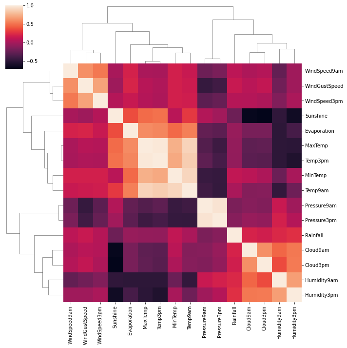

```python
correlations = weather.corr()

plt.figure(figsize=(15,10))
#sns.heatmap(correlations)
sns.clustermap(correlations)
```

Si analizamos el mapa de calor nos damos cuenta de las siguientes cosas:

1. Las variables **MaxTemp** y **Temp3pm**, temperatura máxima y la temperatura a las 3pm, son prácticamente iguales. Por lo tanto, podríamos prescindir de una de ellas dado que no aportan nada nuevo.
2. Si nos fijamos en las variables **MinTemp** y **Temp9am**, temperatura mínima y la temperatura a las 9am, nos encontramos con lo mismo que antes. Al ser prácticamente iguales podemos prescindir de una de ellas al igual que hacíamos con temperatura máxima.
3. Lo mismo pasa con **Pressure9am** y **Pressure3pm**, por lo tanto nos quedamos con solo una de las presiones registradas.

Vamos a comprobar gráficamente lo comentado, si superponemos una variables con otras nos sale que son prácticamente iguales. Por ejemplo, para la temperatura máxima y la temperatura a las 3pm:

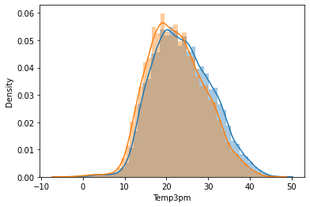

```python
# Comparación entre MaxTemp y Temp3pm para el resultado 'No'.
sns.distplot(weather.loc[weather['RainTomorrow']=='No', 'MaxTemp'])
sns.distplot(weather.loc[weather['RainTomorrow']=='No', 'Temp3pm'])
```

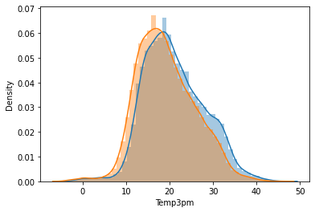

```python
# Comparación entre MaxTemp y Temp3pm para el resultado 'Si'.
sns.distplot(weather.loc[weather['RainTomorrow']=='Yes', 'MaxTemp'])
sns.distplot(weather.loc[weather['RainTomorrow']=='Yes', 'Temp3pm'])
```

Sin embargo, si analizamos mejor la temperatura mínima y la temperatura a las 9am nos damos cuenta de que es más diferencial de lo que nos había parecido en un primer momento. Por lo tanto, alomejor debemos conservarla ya que no es tan clara como lo es la temperatura máxima.

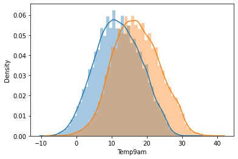

```python
# Comparación entre MinTemp y Temp9am para el resultado 'No'.
sns.distplot(weather.loc[weather['RainTomorrow']=='No', 'MinTemp'])
sns.distplot(weather.loc[weather['RainTomorrow']=='No', 'Temp9am'])
```

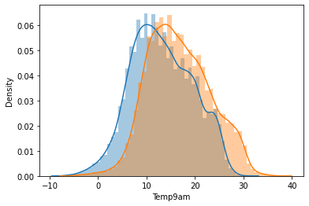

```python
# Comparación entre MinTemp y Temp9am para el resultado 'Si'.
sns.distplot(weather.loc[weather['RainTomorrow']=='Yes', 'MinTemp'])
sns.distplot(weather.loc[weather['RainTomorrow']=='Yes', 'Temp9am'])
```

Por último, analizando más a fondo la comparación entre las distintas presiones registradas nos damos cuenta que son lo suficientemente parecidas como para poder prescindir de una de ellas.

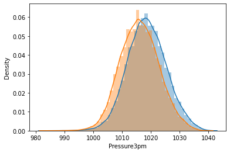

```python
# Comparación entre Pressure9am y Pressure3pm para el resultado 'No'.
sns.distplot(weather.loc[weather['RainTomorrow']=='No', 'Pressure9am'])
sns.distplot(weather.loc[weather['RainTomorrow']=='No', 'Pressure3pm'])
```

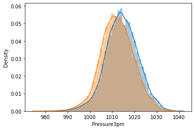

```python
# Comparación entre Pressure9am y Pressure3pm para el resultado 'No'.
sns.distplot(weather.loc[weather['RainTomorrow']=='Yes', 'Pressure9am'])
sns.distplot(weather.loc[weather['RainTomorrow']=='Yes', 'Pressure3pm'])
```

### Conclusión

Aunque nos parezca en un primer momento una buena selección en el mapa de calor debemos comprobar a fondo cada variable. Por lo tanto, en nuestro conjunto de datos podemos prescindir finalmente de una de las variables de temperatura máxima y de presión atmosférica, lo cuál tiene sentido dado las horas registradas de las variables. Al contrario que con la temperatura mínima y la temperatura a las 9am, que también tiene sentido dado que las menores temperaturas se dan de madrugada lo que hace lo suficientemente diferencial para no prescindir de ella.

Una vez analizadas las variables continuas tenemos que ver como se comportan la variables categóricas. Para ello comenzaremos viendo lo diferencial que es la localización en donde nos encontremos, veremos en cada localización el número de **'No'** y de **'Yes'** en la predicción.

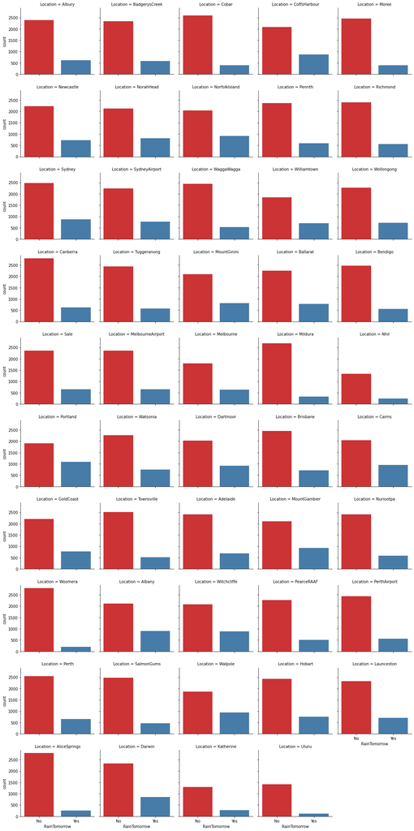

```python
facet = sns.FacetGrid(data=weather, col="Location", col_wrap=5)
# Hay que especificar el order, ya que si no, la primera columna depende del primer elemento encontrado
facet.map_dataframe(sns.countplot, "RainTomorrow", order=['No', 'Yes'], palette='Set1')
```

Si analizamos por **Location** nos damos cuenta que según en que zona esten tomados los datos tenemos unos resultados diferenciales. Por ejemplo, en Woomera apenas llueve mientras que en Caims llueve muchas más veces. Esta variables nos es muy útil ya que nos permite agrupar por localización y así rellenar valores NaN con los valores conrrespondientes a cada zona. Aproximando mejor así a la hora de rellenar los datos perdidos.

Por último, veremos el resto de variables categóricas que nos quedan por analizar.

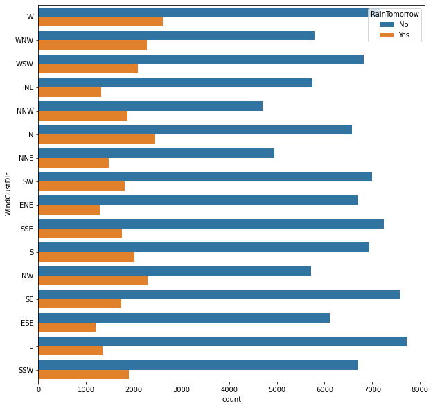

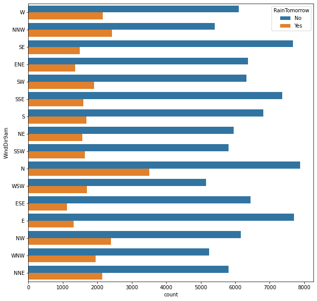

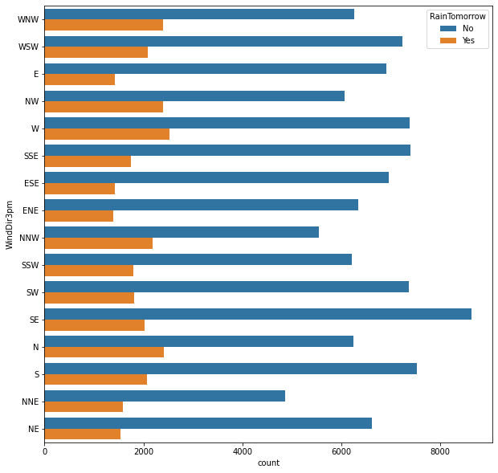

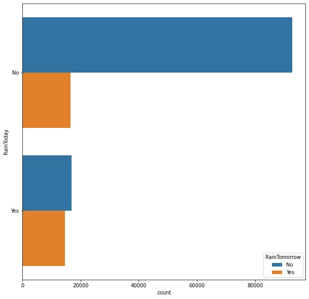

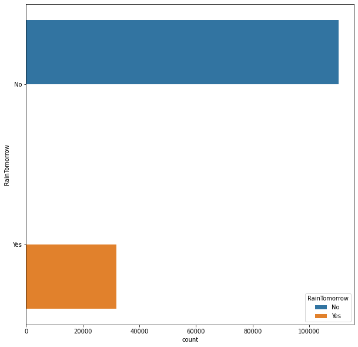

```python
plt.figure(figsize=(10,10))
sns.countplot(data=weather, y='WindGustDir', hue='RainTomorrow')
plt.show()

plt.figure(figsize=(10,10))
sns.countplot(data=weather, y='WindDir9am', hue='RainTomorrow')
plt.show()

plt.figure(figsize=(10,10))
sns.countplot(data=weather, y='WindDir3pm', hue='RainTomorrow')
plt.show()

plt.figure(figsize=(10,10))
sns.countplot(data=weather, y='RainToday', hue='RainTomorrow')
plt.show()

plt.figure(figsize=(10,10))
sns.countplot(data=weather, y='RainTomorrow', hue='RainTomorrow')
plt.show()
```

### Ajustes de nuestros datos

Concluido el análisis de nuestro conjunto de datos procedemos a prescindir de aquellas variables que no son importantes, facilitando nuestro manejo con dicho conjunto. Dichas variables serán *Date* (que hemos eliminado anteriormente), dado que no nos aporta nada, *Temp3pm* y *Pressure3pm*, como hemos visto antes.

```python
# Eliminamos dichas variables.
del(weather['Temp3pm'])
del(weather['Pressure3pm'])
weather
```

|  | Location | MinTemp | MaxTemp | Rainfall | Evaporation | Sunshine | WindGustDir | WindGustSpeed | WindDir9am | WindDir3pm | WindSpeed9am | WindSpeed3pm | Humidity9am | Humidity3pm | Pressure9am | Cloud9am | Cloud3pm | Temp9am | RainToday | RainTomorrow |
| --- | --- | --- | --- | --- | --- | --- | --- | --- | --- | --- | --- | --- | --- | --- | --- | --- | --- | --- | --- | --- |
| 0 | Albury | 13.4 | 22.9 | 0.6 | NaN | NaN | W | 44.0 | W | WNW | 20.0 | 24.0 | 71.0 | 22.0 | 1007.7 | 8.0 | NaN | 16.9 | No | No |
| 1 | Albury | 7.4 | 25.1 | 0.0 | NaN | NaN | WNW | 44.0 | NNW | WSW | 4.0 | 22.0 | 44.0 | 25.0 | 1010.6 | NaN | NaN | 17.2 | No | No |
| 2 | Albury | 12.9 | 25.7 | 0.0 | NaN | NaN | WSW | 46.0 | W | WSW | 19.0 | 26.0 | 38.0 | 30.0 | 1007.6 | NaN | 2.0 | 21.0 | No | No |
| 3 | Albury | 9.2 | 28.0 | 0.0 | NaN | NaN | NE | 24.0 | SE | E | 11.0 | 9.0 | 45.0 | 16.0 | 1017.6 | NaN | NaN | 18.1 | No | No |
| 4 | Albury | 17.5 | 32.3 | 1.0 | NaN | NaN | W | 41.0 | ENE | NW | 7.0 | 20.0 | 82.0 | 33.0 | 1010.8 | 7.0 | 8.0 | 17.8 | No | No |
| ... | ... | ... | ... | ... | ... | ... | ... | ... | ... | ... | ... | ... | ... | ... | ... | ... | ... | ... | ... | ... |
| 145455 | Uluru | 2.8 | 23.4 | 0.0 | NaN | NaN | E | 31.0 | SE | ENE | 13.0 | 11.0 | 51.0 | 24.0 | 1024.6 | NaN | NaN | 10.1 | No | No |
| 145456 | Uluru | 3.6 | 25.3 | 0.0 | NaN | NaN | NNW | 22.0 | SE | N | 13.0 | 9.0 | 56.0 | 21.0 | 1023.5 | NaN | NaN | 10.9 | No | No |
| 145457 | Uluru | 5.4 | 26.9 | 0.0 | NaN | NaN | N | 37.0 | SE | WNW | 9.0 | 9.0 | 53.0 | 24.0 | 1021.0 | NaN | NaN | 12.5 | No | No |
| 145458 | Uluru | 7.8 | 27.0 | 0.0 | NaN | NaN | SE | 28.0 | SSE | N | 13.0 | 7.0 | 51.0 | 24.0 | 1019.4 | 3.0 | 2.0 | 15.1 | No | No |
| 145459 | Uluru | 14.9 | NaN | 0.0 | NaN | NaN | NaN | NaN | ESE | ESE | 17.0 | 17.0 | 62.0 | 36.0 | 1020.2 | 8.0 | 8.0 | 15.0 | No | NaN |

145460 rows × 20 columns

```python
# Recalculamos cuales son los atributos
features = weather.columns
attributes = features[:-1]
target = features[-1]
```

# 3. Normalización de variables discretas

En esta práctica nos encontramos ante un problema con las variables categóricas si queremos utilizar el árbol de decisión de `SciKit` y con valores vacios o NaN. Por lo tanto, debemos modificar aquellas variables categóricas para que puedan ser utilizadas, habra caso donde deberemos hacer un tratamiento binario, en el caso de **RainToday** y **RainTomorrow**, pero en el resto deberemos hacer un tratamiento OneHotEncoder. Pero antes de ello debermos rellenar aquellos valores vacios o NaN que nos encontremos. Deberemos hacer lo siguiente:

### Rellenar valores NaN

Para rellenar dichos valores en nuestro conjunto de datos deberemos utilizar [*fillna*](https://pandas.pydata.org/docs/reference/api/pandas.DataFrame.fillna.html), un método que nos proporciona pandas para el tratamiento y promedio de nuestros conjuntos de datos NaN. Para ello creamos unos métodos los cuáles agrupan por localización para promediar los valores perdidos con la media de dicha localización, si resulta que no tiene ningún registro se promedia con la media global de dicha variable. En el caso de las variables categóricas se realizará con la moda en lugar de con la media.

### Tratamiento sobre variables categóricas

Una vez rellenados aquellos valores que faltaban deberemos hacer un tratamiento sobre aquellas variables categóricas como hemos hablado anteriormente, para ello se nos recomendaba buscar y entender `OneHotEncoder`, pero a la hora de realizar nuestra búsqueda encontramos un método que nos ofrecia pandas el cuál nos facilitaba mucho el tratamiento de estas variables. El método es [_get*dummies*](https://pandas.pydata.org/docs/reference/api/pandas.get_dummies.html) y es muy sencillo de utilizar, eliges a que columna de variables categóricas quieres aplicar OneHotEncoder y eliges el prefijo para cada columna resultante, una vez aplicado lo juntas con tu anterior conjunto de datos eliminando la variable seleccionada. Por lo tanto, es mucho más sencillo realizar el tratamiento con lo que nos ofrece pandas.

### Tratamiento binario

Para aquellas variables como **RainToday** y **RainTomorrow** realizaremos el siguiente tratamiento: aquellos valores clasificados como 'No' pasarán a ser 0 y aquellos valores clasificados como 'Yes' pasarán a ser 1. Para realizar esto de una forma muy sencilla echamos mano a pandas y su método sobre DataFrames [replace](https://pandas.pydata.org/docs/reference/api/pandas.DataFrame.replace.html), en el cual elegimos cuales son los valores que queremos cambiar y porque valores los queremos cambiar.

Así sería el tratamiento realizado sobre *RainToday*, rellenamos aquellos valores NaN y reemplazamos para que queden los valores clasificados como 0 o 1.

```python
weather['RainToday'].fillna(value=0, inplace=True) # Rellenamos aquellos valores NaN
weather['RainToday'].replace('No',0, inplace=True) # Realizamos el tratamiento binario, a 0 y 1.
weather['RainToday'].replace('Yes',1, inplace=True)
weather
```

|  | Location | MinTemp | MaxTemp | Rainfall | Evaporation | Sunshine | WindGustDir | WindGustSpeed | WindDir9am | WindDir3pm | WindSpeed9am | WindSpeed3pm | Humidity9am | Humidity3pm | Pressure9am | Cloud9am | Cloud3pm | Temp9am | RainToday | RainTomorrow |
| --- | --- | --- | --- | --- | --- | --- | --- | --- | --- | --- | --- | --- | --- | --- | --- | --- | --- | --- | --- | --- |
| 0 | Albury | 13.4 | 22.9 | 0.6 | NaN | NaN | W | 44.0 | W | WNW | 20.0 | 24.0 | 71.0 | 22.0 | 1007.7 | 8.0 | NaN | 16.9 | 0 | No |
| 1 | Albury | 7.4 | 25.1 | 0.0 | NaN | NaN | WNW | 44.0 | NNW | WSW | 4.0 | 22.0 | 44.0 | 25.0 | 1010.6 | NaN | NaN | 17.2 | 0 | No |
| 2 | Albury | 12.9 | 25.7 | 0.0 | NaN | NaN | WSW | 46.0 | W | WSW | 19.0 | 26.0 | 38.0 | 30.0 | 1007.6 | NaN | 2.0 | 21.0 | 0 | No |
| 3 | Albury | 9.2 | 28.0 | 0.0 | NaN | NaN | NE | 24.0 | SE | E | 11.0 | 9.0 | 45.0 | 16.0 | 1017.6 | NaN | NaN | 18.1 | 0 | No |
| 4 | Albury | 17.5 | 32.3 | 1.0 | NaN | NaN | W | 41.0 | ENE | NW | 7.0 | 20.0 | 82.0 | 33.0 | 1010.8 | 7.0 | 8.0 | 17.8 | 0 | No |
| ... | ... | ... | ... | ... | ... | ... | ... | ... | ... | ... | ... | ... | ... | ... | ... | ... | ... | ... | ... | ... |
| 145455 | Uluru | 2.8 | 23.4 | 0.0 | NaN | NaN | E | 31.0 | SE | ENE | 13.0 | 11.0 | 51.0 | 24.0 | 1024.6 | NaN | NaN | 10.1 | 0 | No |
| 145456 | Uluru | 3.6 | 25.3 | 0.0 | NaN | NaN | NNW | 22.0 | SE | N | 13.0 | 9.0 | 56.0 | 21.0 | 1023.5 | NaN | NaN | 10.9 | 0 | No |
| 145457 | Uluru | 5.4 | 26.9 | 0.0 | NaN | NaN | N | 37.0 | SE | WNW | 9.0 | 9.0 | 53.0 | 24.0 | 1021.0 | NaN | NaN | 12.5 | 0 | No |
| 145458 | Uluru | 7.8 | 27.0 | 0.0 | NaN | NaN | SE | 28.0 | SSE | N | 13.0 | 7.0 | 51.0 | 24.0 | 1019.4 | 3.0 | 2.0 | 15.1 | 0 | No |
| 145459 | Uluru | 14.9 | NaN | 0.0 | NaN | NaN | NaN | NaN | ESE | ESE | 17.0 | 17.0 | 62.0 | 36.0 | 1020.2 | 8.0 | 8.0 | 15.0 | 0 | NaN |

145460 rows × 20 columns

A continuación, realizamos los métodos que utilizaremos para rellenar aquellos valores NaN que nos encontremos en nuestro conjunto de datos. Nos encontramos con un método al cual le pasaremos nuestro conjunto de datos, es **fillAll()**, el cual nos agrupa por ciudades para tener un mejor promedio y separa según el tipo de datos. Los separa entre aquellas variables que son de tipo float y aquellas que son de tipo object, ya que deberemos diferenciar entre media y moda.

- Si las variables son de **tipo float** los métodos que se llegarán a accionar son *fillAllFloat()*, el cual recorre cada variable del conjunto, y *fillNanValues()*, que rellena aquellos valores NaN con la media de dichos conjunto o con la media global.
- Si las variables son de **tipo object** los métodos que se llegarán a accionar son *fillAllObject()*, el cual recorre cada variable del conjunto al igual que lo hacíamos con los de tipo float, y *fillNanCategoric()*, que rellena aquellos valores NaN con la moda de dichos conjunto o con la moda global.

```python
# RELLENAR NAN
pd.set_option('chained_assignment',None)

# Para rellenar aquellas variables continuas
def fillNanValues(data, colum):

    mean = data[colum].mean() # Calculamos la media
    meanColum = weather[colum].mean()

    if np.isnan(mean):
        weather_wnan = pd.DataFrame(data[colum].fillna(value=weather[colum].mean(), inplace=True)) # Reemplazamos con la media global en caso de tener todos los valores NaN.
    else:
        weather_wnan = pd.DataFrame(data[colum].fillna(value=mean, inplace=True))
    new_weather_wnan = data.join(weather_wnan)

    return new_weather_wnan

def fillAllFloat(data):
    atributes = data.columns
    natr = atributes.size

    for n in range(natr):
        new_data = fillNanValues(data, f"{atributes[n]}")

    return new_data


# Para rellenar aquellas variables categóricas
def fillNanCategoric(data, colum):
    try:
        a = data[colum].mode() # Calculamos cual es la moda
        mode = a[0]
    except:
        b = weather[colum].mode()
        mode = b[0]

    weather_wnan = pd.DataFrame(data[colum].fillna(value=mode, inplace=True)) # Reemplazamos por la moda
    new_weather_wnan = data.join(weather_wnan)

    return new_weather_wnan

def fillAllObject(data):
    atributes = data.columns
    natr = atributes.size

    for n in range(natr):
        new_data = fillNanCategoric(data, f"{atributes[n]}")

    return new_data
```

```python
def fillAll(data):

    for n in cities:
        weatherCities = data[data['Location'] == n] # Para separar por localizaciones
        weatherFloat = weatherCities.select_dtypes(include=['float64'], exclude=['int64']) # Para diferenciar entre variables continuas y categóricas
        new_weatherFloat = fillAllFloat(weatherFloat)

        weatherObject = weatherCities.select_dtypes(exclude=['float64', 'int64'])
        new_weatherObject = fillAllObject(weatherObject)

        weatherCities.fillna(value=new_weatherFloat, inplace = True)
        weatherCities.fillna(value=new_weatherObject, inplace = True)
        data.fillna(value=weatherCities, inplace = True)

    return data
```

```python
new_weather = fillAll(weather)
new_weather
```

|  | Location | MinTemp | MaxTemp | Rainfall | Evaporation | Sunshine | WindGustDir | WindGustSpeed | WindDir9am | WindDir3pm | WindSpeed9am | WindSpeed3pm | Humidity9am | Humidity3pm | Pressure9am | Cloud9am | Cloud3pm | Temp9am | RainToday | RainTomorrow |
| --- | --- | --- | --- | --- | --- | --- | --- | --- | --- | --- | --- | --- | --- | --- | --- | --- | --- | --- | --- | --- |
| 0 | Albury | 13.4 | 22.900000 | 0.6 | 5.468232 | 7.611178 | W | 44.000000 | W | WNW | 20.0 | 24.0 | 71.0 | 22.0 | 1007.7 | 8.000000 | 5.406447 | 16.9 | 0 | No |
| 1 | Albury | 7.4 | 25.100000 | 0.0 | 5.468232 | 7.611178 | WNW | 44.000000 | NNW | WSW | 4.0 | 22.0 | 44.0 | 25.0 | 1010.6 | 6.391001 | 5.406447 | 17.2 | 0 | No |
| 2 | Albury | 12.9 | 25.700000 | 0.0 | 5.468232 | 7.611178 | WSW | 46.000000 | W | WSW | 19.0 | 26.0 | 38.0 | 30.0 | 1007.6 | 6.391001 | 2.000000 | 21.0 | 0 | No |
| 3 | Albury | 9.2 | 28.000000 | 0.0 | 5.468232 | 7.611178 | NE | 24.000000 | SE | E | 11.0 | 9.0 | 45.0 | 16.0 | 1017.6 | 6.391001 | 5.406447 | 18.1 | 0 | No |
| 4 | Albury | 17.5 | 32.300000 | 1.0 | 5.468232 | 7.611178 | W | 41.000000 | ENE | NW | 7.0 | 20.0 | 82.0 | 33.0 | 1010.8 | 7.000000 | 8.000000 | 17.8 | 0 | No |
| ... | ... | ... | ... | ... | ... | ... | ... | ... | ... | ... | ... | ... | ... | ... | ... | ... | ... | ... | ... | ... |
| 145455 | Uluru | 2.8 | 23.400000 | 0.0 | 5.444427 | 7.635899 | E | 31.000000 | SE | ENE | 13.0 | 11.0 | 51.0 | 24.0 | 1024.6 | 5.543103 | 4.834532 | 10.1 | 0 | No |
| 145456 | Uluru | 3.6 | 25.300000 | 0.0 | 5.444427 | 7.635899 | NNW | 22.000000 | SE | N | 13.0 | 9.0 | 56.0 | 21.0 | 1023.5 | 5.543103 | 4.834532 | 10.9 | 0 | No |
| 145457 | Uluru | 5.4 | 26.900000 | 0.0 | 5.444427 | 7.635899 | N | 37.000000 | SE | WNW | 9.0 | 9.0 | 53.0 | 24.0 | 1021.0 | 5.543103 | 4.834532 | 12.5 | 0 | No |
| 145458 | Uluru | 7.8 | 27.000000 | 0.0 | 5.444427 | 7.635899 | SE | 28.000000 | SSE | N | 13.0 | 7.0 | 51.0 | 24.0 | 1019.4 | 3.000000 | 2.000000 | 15.1 | 0 | No |
| 145459 | Uluru | 14.9 | 30.383195 | 0.0 | 5.444427 | 7.635899 | E | 41.268373 | ESE | ESE | 17.0 | 17.0 | 62.0 | 36.0 | 1020.2 | 8.000000 | 8.000000 | 15.0 | 0 | No |

145460 rows × 20 columns

Guardaremos dicho DataFrame para el segunda parte de la práctica, ya que estan todos los valores NaN tratados. Para ello utilizamos pandas y el método [to_csv](https://pandas.pydata.org/docs/reference/api/pandas.DataFrame.to_csv.html), que nos permite guardar en un .csv nuestro conjunto de datos resultante.

```python
new_weather.to_csv('weatherAUS_withoutNaN.csv', header=True, index=False)
```

A continuación, realizamos el tratamiento para las variables categóricas una vez que ya no tienen valores NaN. Para ello utilizaremos como hemos comentadao anteriormente **get_dummies**, al que le pasaremos sobre que variable queremos realizarlo y con que prefijo queremos que se guarde. Por ejemplo, para este primer caso queremos realizarlo sobre *WindGustDir* y de prefijo tendremos el mismo nombre, luego una vez juntado deberemos borrar dicha columna. Y así con el resto de variables categóricas que nos quedan por tratar.

```python
ohe_weather = pd.get_dummies(new_weather.WindGustDir, prefix='WindGustDir') # Realizamos OneHotEncoder sobre aquellas variables categóricas
tree_weather = pd.concat([new_weather, ohe_weather], axis=1)
del(tree_weather['WindGustDir']) # Eliminamos la variable categórica seleccionada

tree_weather
```

|  | Location | MinTemp | MaxTemp | Rainfall | Evaporation | Sunshine | WindGustSpeed | WindDir9am | WindDir3pm | WindSpeed9am | ... | WindGustDir_NNW | WindGustDir_NW | WindGustDir_S | WindGustDir_SE | WindGustDir_SSE | WindGustDir_SSW | WindGustDir_SW | WindGustDir_W | WindGustDir_WNW | WindGustDir_WSW |
| --- | --- | --- | --- | --- | --- | --- | --- | --- | --- | --- | --- | --- | --- | --- | --- | --- | --- | --- | --- | --- | --- |
| 0 | Albury | 13.4 | 22.900000 | 0.6 | 5.468232 | 7.611178 | 44.000000 | W | WNW | 20.0 | ... | 0 | 0 | 0 | 0 | 0 | 0 | 0 | 1 | 0 | 0 |
| 1 | Albury | 7.4 | 25.100000 | 0.0 | 5.468232 | 7.611178 | 44.000000 | NNW | WSW | 4.0 | ... | 0 | 0 | 0 | 0 | 0 | 0 | 0 | 0 | 1 | 0 |
| 2 | Albury | 12.9 | 25.700000 | 0.0 | 5.468232 | 7.611178 | 46.000000 | W | WSW | 19.0 | ... | 0 | 0 | 0 | 0 | 0 | 0 | 0 | 0 | 0 | 1 |
| 3 | Albury | 9.2 | 28.000000 | 0.0 | 5.468232 | 7.611178 | 24.000000 | SE | E | 11.0 | ... | 0 | 0 | 0 | 0 | 0 | 0 | 0 | 0 | 0 | 0 |
| 4 | Albury | 17.5 | 32.300000 | 1.0 | 5.468232 | 7.611178 | 41.000000 | ENE | NW | 7.0 | ... | 0 | 0 | 0 | 0 | 0 | 0 | 0 | 1 | 0 | 0 |
| ... | ... | ... | ... | ... | ... | ... | ... | ... | ... | ... | ... | ... | ... | ... | ... | ... | ... | ... | ... | ... | ... |
| 145455 | Uluru | 2.8 | 23.400000 | 0.0 | 5.444427 | 7.635899 | 31.000000 | SE | ENE | 13.0 | ... | 0 | 0 | 0 | 0 | 0 | 0 | 0 | 0 | 0 | 0 |
| 145456 | Uluru | 3.6 | 25.300000 | 0.0 | 5.444427 | 7.635899 | 22.000000 | SE | N | 13.0 | ... | 1 | 0 | 0 | 0 | 0 | 0 | 0 | 0 | 0 | 0 |
| 145457 | Uluru | 5.4 | 26.900000 | 0.0 | 5.444427 | 7.635899 | 37.000000 | SE | WNW | 9.0 | ... | 0 | 0 | 0 | 0 | 0 | 0 | 0 | 0 | 0 | 0 |
| 145458 | Uluru | 7.8 | 27.000000 | 0.0 | 5.444427 | 7.635899 | 28.000000 | SSE | N | 13.0 | ... | 0 | 0 | 0 | 1 | 0 | 0 | 0 | 0 | 0 | 0 |
| 145459 | Uluru | 14.9 | 30.383195 | 0.0 | 5.444427 | 7.635899 | 41.268373 | ESE | ESE | 17.0 | ... | 0 | 0 | 0 | 0 | 0 | 0 | 0 | 0 | 0 | 0 |

145460 rows × 35 columns

```python
ohe_weather = pd.get_dummies(tree_weather.WindDir9am, prefix='WindDir9am')
tree_weather = pd.concat([tree_weather, ohe_weather], axis=1)
del(tree_weather['WindDir9am'])

tree_weather
```

|  | Location | MinTemp | MaxTemp | Rainfall | Evaporation | Sunshine | WindGustSpeed | WindDir3pm | WindSpeed9am | WindSpeed3pm | ... | WindDir9am_NNW | WindDir9am_NW | WindDir9am_S | WindDir9am_SE | WindDir9am_SSE | WindDir9am_SSW | WindDir9am_SW | WindDir9am_W | WindDir9am_WNW | WindDir9am_WSW |
| --- | --- | --- | --- | --- | --- | --- | --- | --- | --- | --- | --- | --- | --- | --- | --- | --- | --- | --- | --- | --- | --- |
| 0 | Albury | 13.4 | 22.900000 | 0.6 | 5.468232 | 7.611178 | 44.000000 | WNW | 20.0 | 24.0 | ... | 0 | 0 | 0 | 0 | 0 | 0 | 0 | 1 | 0 | 0 |
| 1 | Albury | 7.4 | 25.100000 | 0.0 | 5.468232 | 7.611178 | 44.000000 | WSW | 4.0 | 22.0 | ... | 1 | 0 | 0 | 0 | 0 | 0 | 0 | 0 | 0 | 0 |
| 2 | Albury | 12.9 | 25.700000 | 0.0 | 5.468232 | 7.611178 | 46.000000 | WSW | 19.0 | 26.0 | ... | 0 | 0 | 0 | 0 | 0 | 0 | 0 | 1 | 0 | 0 |
| 3 | Albury | 9.2 | 28.000000 | 0.0 | 5.468232 | 7.611178 | 24.000000 | E | 11.0 | 9.0 | ... | 0 | 0 | 0 | 1 | 0 | 0 | 0 | 0 | 0 | 0 |
| 4 | Albury | 17.5 | 32.300000 | 1.0 | 5.468232 | 7.611178 | 41.000000 | NW | 7.0 | 20.0 | ... | 0 | 0 | 0 | 0 | 0 | 0 | 0 | 0 | 0 | 0 |
| ... | ... | ... | ... | ... | ... | ... | ... | ... | ... | ... | ... | ... | ... | ... | ... | ... | ... | ... | ... | ... | ... |
| 145455 | Uluru | 2.8 | 23.400000 | 0.0 | 5.444427 | 7.635899 | 31.000000 | ENE | 13.0 | 11.0 | ... | 0 | 0 | 0 | 1 | 0 | 0 | 0 | 0 | 0 | 0 |
| 145456 | Uluru | 3.6 | 25.300000 | 0.0 | 5.444427 | 7.635899 | 22.000000 | N | 13.0 | 9.0 | ... | 0 | 0 | 0 | 1 | 0 | 0 | 0 | 0 | 0 | 0 |
| 145457 | Uluru | 5.4 | 26.900000 | 0.0 | 5.444427 | 7.635899 | 37.000000 | WNW | 9.0 | 9.0 | ... | 0 | 0 | 0 | 1 | 0 | 0 | 0 | 0 | 0 | 0 |
| 145458 | Uluru | 7.8 | 27.000000 | 0.0 | 5.444427 | 7.635899 | 28.000000 | N | 13.0 | 7.0 | ... | 0 | 0 | 0 | 0 | 1 | 0 | 0 | 0 | 0 | 0 |
| 145459 | Uluru | 14.9 | 30.383195 | 0.0 | 5.444427 | 7.635899 | 41.268373 | ESE | 17.0 | 17.0 | ... | 0 | 0 | 0 | 0 | 0 | 0 | 0 | 0 | 0 | 0 |

145460 rows × 50 columns

```python
ohe_weather = pd.get_dummies(tree_weather.WindDir3pm, prefix='WindDir3pm')
tree_weather = pd.concat([tree_weather, ohe_weather], axis=1)
del(tree_weather['WindDir3pm'])

tree_weather
```

|  | Location | MinTemp | MaxTemp | Rainfall | Evaporation | Sunshine | WindGustSpeed | WindSpeed9am | WindSpeed3pm | Humidity9am | ... | WindDir3pm_NNW | WindDir3pm_NW | WindDir3pm_S | WindDir3pm_SE | WindDir3pm_SSE | WindDir3pm_SSW | WindDir3pm_SW | WindDir3pm_W | WindDir3pm_WNW | WindDir3pm_WSW |
| --- | --- | --- | --- | --- | --- | --- | --- | --- | --- | --- | --- | --- | --- | --- | --- | --- | --- | --- | --- | --- | --- |
| 0 | Albury | 13.4 | 22.900000 | 0.6 | 5.468232 | 7.611178 | 44.000000 | 20.0 | 24.0 | 71.0 | ... | 0 | 0 | 0 | 0 | 0 | 0 | 0 | 0 | 1 | 0 |
| 1 | Albury | 7.4 | 25.100000 | 0.0 | 5.468232 | 7.611178 | 44.000000 | 4.0 | 22.0 | 44.0 | ... | 0 | 0 | 0 | 0 | 0 | 0 | 0 | 0 | 0 | 1 |
| 2 | Albury | 12.9 | 25.700000 | 0.0 | 5.468232 | 7.611178 | 46.000000 | 19.0 | 26.0 | 38.0 | ... | 0 | 0 | 0 | 0 | 0 | 0 | 0 | 0 | 0 | 1 |
| 3 | Albury | 9.2 | 28.000000 | 0.0 | 5.468232 | 7.611178 | 24.000000 | 11.0 | 9.0 | 45.0 | ... | 0 | 0 | 0 | 0 | 0 | 0 | 0 | 0 | 0 | 0 |
| 4 | Albury | 17.5 | 32.300000 | 1.0 | 5.468232 | 7.611178 | 41.000000 | 7.0 | 20.0 | 82.0 | ... | 0 | 1 | 0 | 0 | 0 | 0 | 0 | 0 | 0 | 0 |
| ... | ... | ... | ... | ... | ... | ... | ... | ... | ... | ... | ... | ... | ... | ... | ... | ... | ... | ... | ... | ... | ... |
| 145455 | Uluru | 2.8 | 23.400000 | 0.0 | 5.444427 | 7.635899 | 31.000000 | 13.0 | 11.0 | 51.0 | ... | 0 | 0 | 0 | 0 | 0 | 0 | 0 | 0 | 0 | 0 |
| 145456 | Uluru | 3.6 | 25.300000 | 0.0 | 5.444427 | 7.635899 | 22.000000 | 13.0 | 9.0 | 56.0 | ... | 0 | 0 | 0 | 0 | 0 | 0 | 0 | 0 | 0 | 0 |
| 145457 | Uluru | 5.4 | 26.900000 | 0.0 | 5.444427 | 7.635899 | 37.000000 | 9.0 | 9.0 | 53.0 | ... | 0 | 0 | 0 | 0 | 0 | 0 | 0 | 0 | 1 | 0 |
| 145458 | Uluru | 7.8 | 27.000000 | 0.0 | 5.444427 | 7.635899 | 28.000000 | 13.0 | 7.0 | 51.0 | ... | 0 | 0 | 0 | 0 | 0 | 0 | 0 | 0 | 0 | 0 |
| 145459 | Uluru | 14.9 | 30.383195 | 0.0 | 5.444427 | 7.635899 | 41.268373 | 17.0 | 17.0 | 62.0 | ... | 0 | 0 | 0 | 0 | 0 | 0 | 0 | 0 | 0 | 0 |

145460 rows × 65 columns

```python
ohe_weather = pd.get_dummies(tree_weather.Location, prefix='Location')
tree_weather = pd.concat([tree_weather, ohe_weather], axis=1)
del(tree_weather['Location'])

tree_weather
```

|  | MinTemp | MaxTemp | Rainfall | Evaporation | Sunshine | WindGustSpeed | WindSpeed9am | WindSpeed3pm | Humidity9am | Humidity3pm | ... | Location_Townsville | Location_Tuggeranong | Location_Uluru | Location_WaggaWagga | Location_Walpole | Location_Watsonia | Location_Williamtown | Location_Witchcliffe | Location_Wollongong | Location_Woomera |
| --- | --- | --- | --- | --- | --- | --- | --- | --- | --- | --- | --- | --- | --- | --- | --- | --- | --- | --- | --- | --- | --- |
| 0 | 13.4 | 22.900000 | 0.6 | 5.468232 | 7.611178 | 44.000000 | 20.0 | 24.0 | 71.0 | 22.0 | ... | 0 | 0 | 0 | 0 | 0 | 0 | 0 | 0 | 0 | 0 |
| 1 | 7.4 | 25.100000 | 0.0 | 5.468232 | 7.611178 | 44.000000 | 4.0 | 22.0 | 44.0 | 25.0 | ... | 0 | 0 | 0 | 0 | 0 | 0 | 0 | 0 | 0 | 0 |
| 2 | 12.9 | 25.700000 | 0.0 | 5.468232 | 7.611178 | 46.000000 | 19.0 | 26.0 | 38.0 | 30.0 | ... | 0 | 0 | 0 | 0 | 0 | 0 | 0 | 0 | 0 | 0 |
| 3 | 9.2 | 28.000000 | 0.0 | 5.468232 | 7.611178 | 24.000000 | 11.0 | 9.0 | 45.0 | 16.0 | ... | 0 | 0 | 0 | 0 | 0 | 0 | 0 | 0 | 0 | 0 |
| 4 | 17.5 | 32.300000 | 1.0 | 5.468232 | 7.611178 | 41.000000 | 7.0 | 20.0 | 82.0 | 33.0 | ... | 0 | 0 | 0 | 0 | 0 | 0 | 0 | 0 | 0 | 0 |
| ... | ... | ... | ... | ... | ... | ... | ... | ... | ... | ... | ... | ... | ... | ... | ... | ... | ... | ... | ... | ... | ... |
| 145455 | 2.8 | 23.400000 | 0.0 | 5.444427 | 7.635899 | 31.000000 | 13.0 | 11.0 | 51.0 | 24.0 | ... | 0 | 0 | 1 | 0 | 0 | 0 | 0 | 0 | 0 | 0 |
| 145456 | 3.6 | 25.300000 | 0.0 | 5.444427 | 7.635899 | 22.000000 | 13.0 | 9.0 | 56.0 | 21.0 | ... | 0 | 0 | 1 | 0 | 0 | 0 | 0 | 0 | 0 | 0 |
| 145457 | 5.4 | 26.900000 | 0.0 | 5.444427 | 7.635899 | 37.000000 | 9.0 | 9.0 | 53.0 | 24.0 | ... | 0 | 0 | 1 | 0 | 0 | 0 | 0 | 0 | 0 | 0 |
| 145458 | 7.8 | 27.000000 | 0.0 | 5.444427 | 7.635899 | 28.000000 | 13.0 | 7.0 | 51.0 | 24.0 | ... | 0 | 0 | 1 | 0 | 0 | 0 | 0 | 0 | 0 | 0 |
| 145459 | 14.9 | 30.383195 | 0.0 | 5.444427 | 7.635899 | 41.268373 | 17.0 | 17.0 | 62.0 | 36.0 | ... | 0 | 0 | 1 | 0 | 0 | 0 | 0 | 0 | 0 | 0 |

145460 rows × 113 columns

```python
tree_weather.info()
```

```
<class 'pandas.core.frame.DataFrame'>
RangeIndex: 145460 entries, 0 to 145459
Columns: 113 entries, MinTemp to Location_Woomera
dtypes: float64(14), int64(1), object(1), uint8(97)
memory usage: 31.2+ MB
```

# 4. Árbol de decisión con SciKit

Una vez hecho el tratamiento sobre nuestro conjunto de datos podremos realizar el árbol de decisión con `Scikit`. Para ello comenzamos separando en **X** el conjunto de datos para predecir, y para **y** la variable *RainTomorrou*. Para facilitar la separación de *RainTomorrow* nos esperamos para realizar el tratamiento binario una vez estén en X aquellas variables de tipo 'float64', 'int64' y 'uint8'.

Al tener separado X e y podemos realizar el árbol de decisión con [DecisionTree](https://scikit-learn.org/stable/modules/generated/sklearn.tree.DecisionTreeClassifier.html#sklearn.tree.DecisionTreeClassifier) de Scikit, para ver representado el árbol utilizaremos `graphviz`. A continuación, compararemos como afecta el cambio de parámetros para el árbol de decisión, _max*depth* y _min_samples*leaves*, en nuesto árbol.

```python
features = tree_weather.columns
attributes = features[:]
X = tree_weather[attributes].select_dtypes(include=['float64', 'int64', 'uint8'])
X
```

|  | MinTemp | MaxTemp | Rainfall | Evaporation | Sunshine | WindGustSpeed | WindSpeed9am | WindSpeed3pm | Humidity9am | Humidity3pm | ... | Location_Townsville | Location_Tuggeranong | Location_Uluru | Location_WaggaWagga | Location_Walpole | Location_Watsonia | Location_Williamtown | Location_Witchcliffe | Location_Wollongong | Location_Woomera |
| --- | --- | --- | --- | --- | --- | --- | --- | --- | --- | --- | --- | --- | --- | --- | --- | --- | --- | --- | --- | --- | --- |
| 0 | 13.4 | 22.900000 | 0.6 | 5.468232 | 7.611178 | 44.000000 | 20.0 | 24.0 | 71.0 | 22.0 | ... | 0 | 0 | 0 | 0 | 0 | 0 | 0 | 0 | 0 | 0 |
| 1 | 7.4 | 25.100000 | 0.0 | 5.468232 | 7.611178 | 44.000000 | 4.0 | 22.0 | 44.0 | 25.0 | ... | 0 | 0 | 0 | 0 | 0 | 0 | 0 | 0 | 0 | 0 |
| 2 | 12.9 | 25.700000 | 0.0 | 5.468232 | 7.611178 | 46.000000 | 19.0 | 26.0 | 38.0 | 30.0 | ... | 0 | 0 | 0 | 0 | 0 | 0 | 0 | 0 | 0 | 0 |
| 3 | 9.2 | 28.000000 | 0.0 | 5.468232 | 7.611178 | 24.000000 | 11.0 | 9.0 | 45.0 | 16.0 | ... | 0 | 0 | 0 | 0 | 0 | 0 | 0 | 0 | 0 | 0 |
| 4 | 17.5 | 32.300000 | 1.0 | 5.468232 | 7.611178 | 41.000000 | 7.0 | 20.0 | 82.0 | 33.0 | ... | 0 | 0 | 0 | 0 | 0 | 0 | 0 | 0 | 0 | 0 |
| ... | ... | ... | ... | ... | ... | ... | ... | ... | ... | ... | ... | ... | ... | ... | ... | ... | ... | ... | ... | ... | ... |
| 145455 | 2.8 | 23.400000 | 0.0 | 5.444427 | 7.635899 | 31.000000 | 13.0 | 11.0 | 51.0 | 24.0 | ... | 0 | 0 | 1 | 0 | 0 | 0 | 0 | 0 | 0 | 0 |
| 145456 | 3.6 | 25.300000 | 0.0 | 5.444427 | 7.635899 | 22.000000 | 13.0 | 9.0 | 56.0 | 21.0 | ... | 0 | 0 | 1 | 0 | 0 | 0 | 0 | 0 | 0 | 0 |
| 145457 | 5.4 | 26.900000 | 0.0 | 5.444427 | 7.635899 | 37.000000 | 9.0 | 9.0 | 53.0 | 24.0 | ... | 0 | 0 | 1 | 0 | 0 | 0 | 0 | 0 | 0 | 0 |
| 145458 | 7.8 | 27.000000 | 0.0 | 5.444427 | 7.635899 | 28.000000 | 13.0 | 7.0 | 51.0 | 24.0 | ... | 0 | 0 | 1 | 0 | 0 | 0 | 0 | 0 | 0 | 0 |
| 145459 | 14.9 | 30.383195 | 0.0 | 5.444427 | 7.635899 | 41.268373 | 17.0 | 17.0 | 62.0 | 36.0 | ... | 0 | 0 | 1 | 0 | 0 | 0 | 0 | 0 | 0 | 0 |

145460 rows × 112 columns

```python
features = X.columns
attributes_r = features[:]
```

```python
tree_weather['RainTomorrow'].fillna(value=0, inplace=True)
tree_weather['RainTomorrow'].replace('No',0, inplace=True)
tree_weather['RainTomorrow'].replace('Yes',1, inplace=True)

y = tree_weather[target]
y
```

```
0         0
1         0
2         0
3         0
4         0
         ..
145455    0
145456    0
145457    0
145458    0
145459    0
Name: RainTomorrow, Length: 145460, dtype: int64
```

```python
from sklearn import tree
from sklearn.metrics import accuracy_score, roc_auc_score
from time import time
```

```python
max_depth = 2
min_samples_leaf = 1
```

```python
t = time()
arbol = tree.DecisionTreeClassifier(criterion='entropy',
                                    max_depth=max_depth,
                                    min_samples_leaf = min_samples_leaf)
arbol.fit(X,y)
t = time() - t
```

```python
arbol.tree_
```

```
<sklearn.tree._tree.Tree at 0x221cc565490>
```

```python
import graphviz
import matplotlib
import matplotlib.pyplot as plt

dot_data = tree.export_graphviz(arbol, out_file=None,
                         feature_names=attributes_r,
                         class_names=['No', 'Yes'],
                         filled=True, rounded=True,
                         special_characters=True)
graph = graphviz.Source(dot_data)
graph
```

[figure not shown]

```python
score = arbol.score(X,y)
roc_score = roc_auc_score(y, arbol.predict(X))
accuracy = accuracy_score(y, arbol.predict(X))
print("Score: ",score)
print("Roc Auc Score: ",roc_score)
print("Accuracy: ", accuracy)
```

```
Score:  0.8240890966588753
Roc Auc Score:  0.6293125913660084
Accuracy:  0.8240890966588753
```

```python
depth = arbol.get_depth()
nodes = arbol.tree_.node_count
leaves = arbol.get_n_leaves()
print("Profundidad: ", depth)
print("Nº nodos: ", nodes)
print("Nº hojas: ", leaves)
print("Time: ", t)
```

```
Profundidad:  2
Nº nodos:  7
Nº hojas:  4
Time:  0.4387474060058594
```

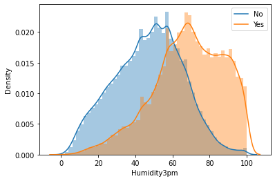

```python
sns.distplot(tree_weather.loc[tree_weather['RainTomorrow'] == 0, 'Humidity3pm'])
sns.distplot(tree_weather.loc[tree_weather['RainTomorrow'] == 1, 'Humidity3pm'])
plt.legend(["No", "Yes"])
```

Como podemos comprobar la variable **Humidity3pm** es lo suficientemente diferencial como para ser la raíz de nuestro árbol de decisión.

# 5. Comparación modificando parámetros

Hemos visto ya como obtener un árbol de decisión con `Scikit`, pero a continuación veremos una comparación entre distintas ejecuciones modificando los parámetros **_max*depth*** y **_min_samples*leaf***. Para realizar dicha comparación guardaremos los resultados obtenidos de todos los árboles y los mostraremos gráficamente, ya que es mucha más intuitivo y sencillo de interpretar, nos apoyaremos en pyplot. Veremos la ganancia, el tiempo de ejecución y la cantidad de nodos abiertos si aumentamos la profundidad. Y veremos también la comparación si decidimos aumentar el número de ejemplos mínimo que tienen que haber en un nodo hoja.

Empezaremos comparando si aumentamos la profundidad máxima, en este caso probaremos para un `max_depth` de 5:

```python
max_depth5 = 5
min_samples_leaf5 = 1
```

```python
t5 = time()
arbol5 = tree.DecisionTreeClassifier(criterion='entropy',
                                    max_depth=max_depth5,
                                    min_samples_leaf = min_samples_leaf5)
arbol5.fit(X,y)
t5 = time() - t5
```

```python
dot_data5 = tree.export_graphviz(arbol5, out_file=None,
                         feature_names=attributes_r,
                         class_names=['No', 'Yes'],
                         filled=True, rounded=True,
                         special_characters=True)
graph = graphviz.Source(dot_data5)
graph
```

[figure not shown]

```python
score5 = arbol5.score(X,y)
roc_score5 = roc_auc_score(y, arbol5.predict(X))
accuracy5 = accuracy_score(y, arbol5.predict(X))
print("Score: ",score5)
print("Roc Auc Score: ",roc_score5)
print("Accuracy: ", accuracy5)
```

```
Score:  0.8387666712498282
Roc Auc Score:  0.6956687151907454
Accuracy:  0.8387666712498282
```

```python
depth5 = arbol5.get_depth()
nodes5 = arbol5.tree_.node_count
leaves5 = arbol5.get_n_leaves()
print("Profundidad: ", depth5)
print("Nº nodos: ", nodes5)
print("Nº hojas: ", leaves5)
print("Time: ", t5)
```

```
Profundidad:  5
Nº nodos:  63
Nº hojas:  32
Time:  0.9744048118591309
```

Ahora ejecutaremos un árbol para un `max_depth` de 8:

```python
max_depth8 = 8
min_samples_leaf8 = 1
```

```python
t8 = time()
arbol8 = tree.DecisionTreeClassifier(criterion='entropy',
                                    max_depth=max_depth8,
                                    min_samples_leaf = min_samples_leaf8)
arbol8.fit(X,y)
t8 = time() - t8
```

```python
dot_data8 = tree.export_graphviz(arbol8, out_file=None,
                         feature_names=attributes_r,
                         class_names=['No', 'Yes'],
                         filled=True, rounded=True,
                         special_characters=True)
graph = graphviz.Source(dot_data8)
graph
```

[figure not shown]

```python
score8 = arbol8.score(X,y)
roc_score8 = roc_auc_score(y, arbol8.predict(X))
accuracy8 = accuracy_score(y, arbol8.predict(X))
print("Score: ",score8)
print("Roc Auc Score: ",roc_score8)
print("Accuracy: ", accuracy8)
```

```
Score:  0.8472226041523443
Roc Auc Score:  0.7133368381726055
Accuracy:  0.8472226041523443
```

```python
depth8 = arbol8.get_depth()
nodes8 = arbol8.tree_.node_count
leaves8 = arbol8.get_n_leaves()
print("Profundidad: ", depth8)
print("Nº nodos: ", nodes8)
print("Nº hojas: ", leaves8)
print("Time: ", t8)
```

```
Profundidad:  8
Nº nodos:  495
Nº hojas:  248
Time:  1.6077113151550293
```

Una vez almacenados todos los resultados de los árboles, en este caso se trata de 3 árboles, podremos compararlos gráficamente como se muestra a continuación:

#### Gráfica 1

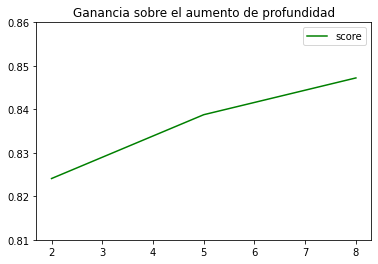

```python
X_plt = [depth, depth5, depth8]
Y_plt = [score, score5, score8]
plt.plot(X_plt,Y_plt,'g-', label='score')
plt.ylim([0.81,0.86])
plt.title('Ganancia sobre el aumento de profundidad')
plt.legend()
plt.show()
```

#### Gráfica 2 y gráfica 3

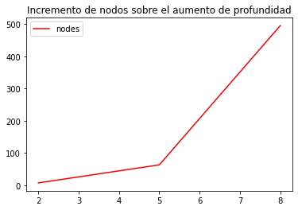

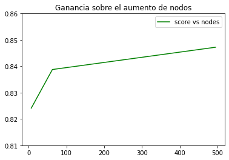

```python
X_plt = [depth, depth5, depth8]
Y_plt = [nodes, nodes5, nodes8]
plt.plot(X_plt,Y_plt,'r-', label='nodes')
plt.title('Incremento de nodos sobre el aumento de profundidad')
plt.legend()
plt.show()

X_plt = [nodes, nodes5, nodes8]
Y_plt = [score, score5, score8]
plt.plot(X_plt,Y_plt,'g-', label='score vs nodes')
plt.ylim([0.81,0.86])
plt.title('Ganancia sobre el aumento de nodos')
plt.legend()
plt.show()
```

#### Gráfica 4

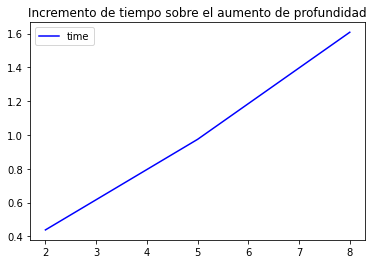

```python
X_plt = [depth, depth5, depth8]
Y_plt = [t, t5, t8]
plt.plot(X_plt,Y_plt,'b-', label='time')
plt.title('Incremento de tiempo sobre el aumento de profundidad')
plt.legend()
plt.show()
```

## Conclusión

Una vez representado los resultados gráficamente podemos pasar a comentar lo más destacable de esta comparación:

- Una mayor profundidad no nos garantiza un gran aumento en la eficacia del resultado. Como podemos ver en la primera gráfica un aumento de la profundidad nos ofrece una ganancia mínima, por lo tanto, tendríamos que ver si nos saldría rentable aumentar la profundidad y el coste que tendría frente al mínimo aumento de ganancia.
- El aumentar la profundidad trae consigo un aumento exponencial de nodos $\theta$($2^n$)y por lo tanto de coste, si nos fijamos en la segunda gráfica podemos observar como crecen los nodos conforme aumentamos la profundidad. Además, si comparamos la ganacia frente al aumento de nodos, nos fijamos en la tercera gráfica, que no obtenemos un aumento de ganancia significativo como para aumentar la profundidad de nuestro ábol.
- Si comparamos el tiempo empleado en cada ejecución de los árboles vemos que tiene un crecimiento prácticamente lineal, lo podemos ver representado en la cuarta gráfica.

A continuación, compararemos como afecta si cambiamos el número de ejemplos mínimos que tienen que caer en un nodo hoja, para esto lo compararemos con el último árbol de decisión dado que tiene un número mayor de nodos. Empezaremos probando para un `min_samples_leaves` de 250:

```python
max_depth2 = 8
min_samples_leaf2 = 250
```

```python
t2 = time()
arbol2 = tree.DecisionTreeClassifier(criterion='entropy',
                                    max_depth=max_depth2,
                                    min_samples_leaf = min_samples_leaf2)
arbol2.fit(X,y)
t2 = time() - t2
```

```python
dot_data2 = tree.export_graphviz(arbol2, out_file=None,
                         feature_names=attributes_r,
                         class_names=['No', 'Yes'],
                         filled=True, rounded=True,
                         special_characters=True)
graph = graphviz.Source(dot_data2)
graph
```

[figure not shown]

```python
score2 = arbol2.score(X,y)
roc_score2 = roc_auc_score(y, arbol2.predict(X))
accuracy2 = accuracy_score(y, arbol2.predict(X))
print("Score: ",score2)
print("Roc Auc Score: ",roc_score2)
print("Accuracy: ", accuracy2)
```

```
Score:  0.8443352124295339
Roc Auc Score:  0.7111494732503665
Accuracy:  0.8443352124295339
```

```python
depth2 = arbol2.get_depth()
nodes2 = arbol2.tree_.node_count
leaves2 = arbol2.get_n_leaves()
print("Profundidad: ", depth2)
print("Nº nodos: ", nodes2)
print("Nº hojas: ", leaves2)
print("Time: ", t2)
```

```
Profundidad:  8
Nº nodos:  337
Nº hojas:  169
Time:  1.7004539966583252
```

Por último, probaremos para un `min_samples_leaves` de 500:

```python
max_depth4 = 8
min_samples_leaf4 = 500
```

```python
t4 = time()
arbol4 = tree.DecisionTreeClassifier(criterion='entropy',
                                    max_depth=max_depth4,
                                    min_samples_leaf = min_samples_leaf4)
arbol4.fit(X,y)
t4 = time() - t4
```

```python
dot_data4 = tree.export_graphviz(arbol4, out_file=None,
                         feature_names=attributes_r,
                         class_names=['No', 'Yes'],
                         filled=True, rounded=True,
                         special_characters=True)
graph = graphviz.Source(dot_data4)
graph
```

[figure not shown]

```python
score4 = arbol4.score(X,y)
roc_score4 = roc_auc_score(y, arbol4.predict(X))
accuracy4 = accuracy_score(y, arbol4.predict(X))
print("Score: ",score4)
print("Roc Auc Score: ",roc_score4)
print("Accuracy: ", accuracy4)
```

```
Score:  0.8418740547229479
Roc Auc Score:  0.6996217303935793
Accuracy:  0.8418740547229479
```

```python
depth4 = arbol4.get_depth()
nodes4 = arbol4.tree_.node_count
leaves4 = arbol4.get_n_leaves()
print("Profundidad: ", depth4)
print("Nº nodos: ", nodes4)
print("Nº hojas: ", leaves4)
print("Time: ", t4)
```

```
Profundidad:  8
Nº nodos:  235
Nº hojas:  118
Time:  1.4701156616210938
```

Una vez almacenado todos los datos obtenidos en las distintas ejecuciones según el número mínimo de ejemplos para cada nodo hoja podemos compararlos gráficamente como hemos hecho anteriormente.

#### Gráfica 5 y gráfica 6

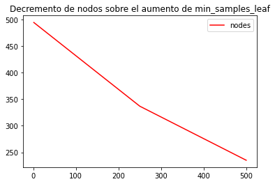

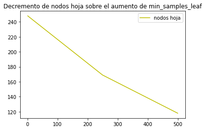

```python
X_plt = [min_samples_leaf8, min_samples_leaf2, min_samples_leaf4]
Y_plt = [nodes8, nodes2, nodes4]
plt.plot(X_plt,Y_plt,'r-', label='nodes')
plt.title('Decremento de nodos sobre el aumento de min_samples_leaf')
plt.legend()
plt.show()

Y_plt = [leaves8, leaves2, leaves4]
plt.plot(X_plt,Y_plt,'y-', label='nodos hoja')
plt.title('Decremento de nodos hoja sobre el aumento de min_samples_leaf')
plt.legend()
plt.show()
```

#### Gráfica 7

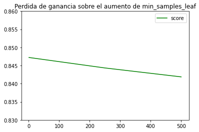

```python
X_plt = [min_samples_leaf8, min_samples_leaf2, min_samples_leaf4]
Y_plt = [score8, score2, score4]
plt.plot(X_plt,Y_plt,'g-', label='score')
plt.title('Perdida de ganancia sobre el aumento de min_samples_leaf')
plt.ylim([0.83,0.86])
plt.legend()
plt.show()
```

#### Gráfica 8

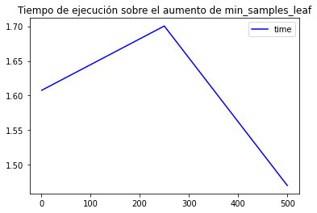

```python
X_plt = [min_samples_leaf8, min_samples_leaf2, min_samples_leaf4]
Y_plt = [t8, t2, t4]
plt.plot(X_plt,Y_plt,'b-', label='time')
plt.title('Tiempo de ejecución sobre el aumento de min_samples_leaf')
plt.legend()
plt.show()
```

## Conclusión

Una vez representado los resultados de _min_samples*leaf* gráficamente podemos pasar a comentar lo más destacable de esta comparación: